# Question

La gráfica muestra las exportaciones del sector alimentario de un país hacia diferentes destinos durante el período 2008-2010, expresadas en millones de dólares. Los principales productos exportados incluyen café y cacao, entre otros.

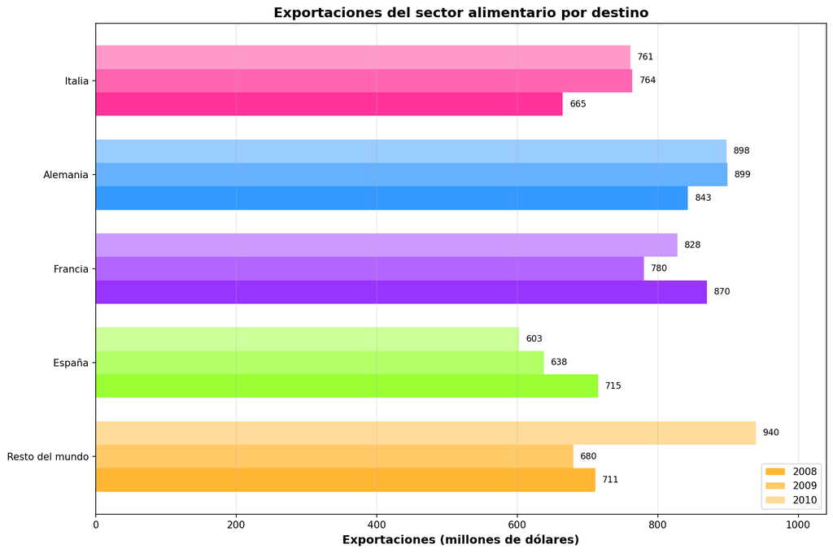

Otra representación que muestra toda la información de la gráfica anterior es:

## Answerlist

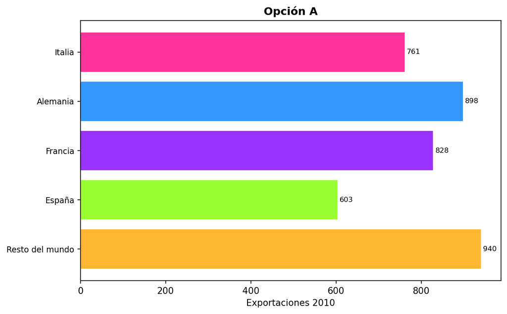

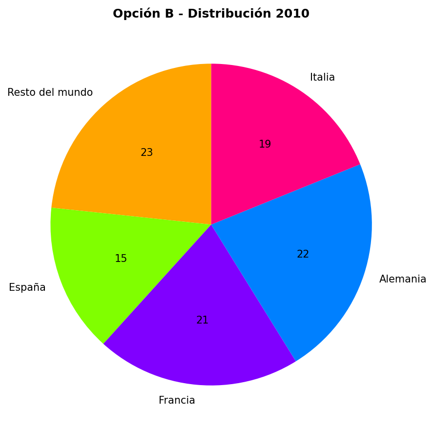

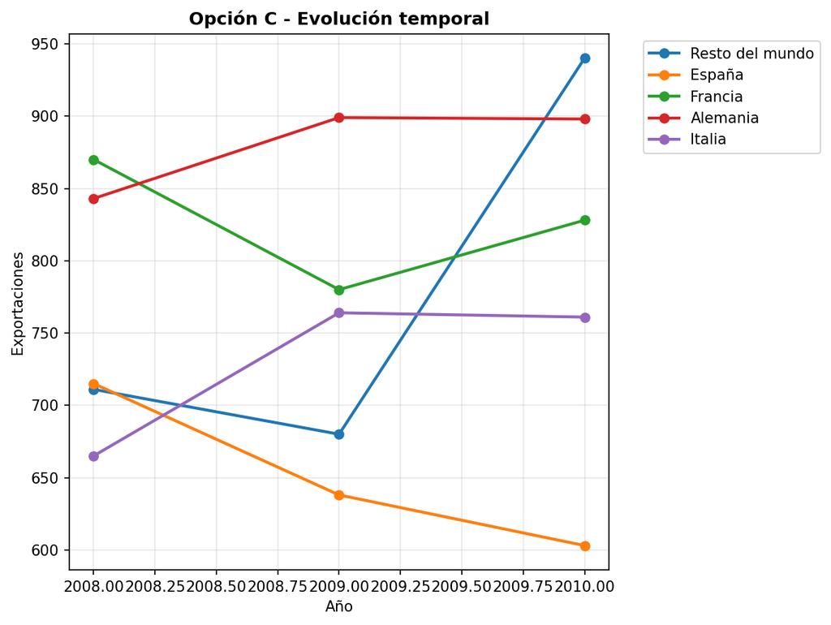

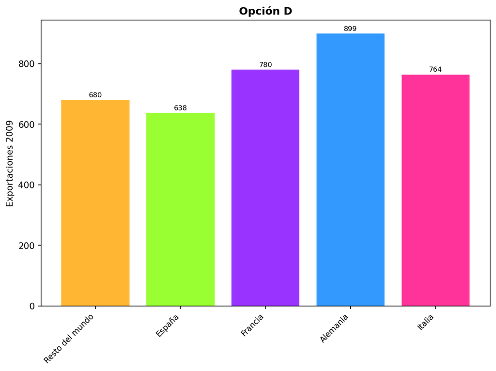

# Solution

Para resolver este problema, debemos analizar qué representación gráfica muestra **toda la información** de la gráfica original de manera equivalente.

### Análisis de la gráfica original:

La gráfica principal muestra: - **Datos de tres años**: 2008, 2009 y 2010 - **Cinco destinos**: Resto del mundo, España, Francia, Alemania, Italia - **Valores específicos** para cada combinación año-destino - **Comparación temporal** entre los diferentes años

### Análisis de cada opción:

**Opción A**: Muestra únicamente los datos de 2010 en formato de barras horizontales. Aunque mantiene la información de todos los destinos para ese año específico, **no incluye** los datos de 2008 y 2009.

**Opción B**: Presenta una gráfica circular con los datos de 2010, mostrando la distribución porcentual entre destinos. **No incluye** información temporal de los otros años.

**Opción C**: Muestra la evolución temporal de las exportaciones mediante líneas, incluyendo **todos los años** (2008, 2009, 2010) y **todos los destinos**. Esta representación permite visualizar tanto los valores específicos como las tendencias temporales.

**Opción D**: Presenta únicamente los datos de 2009 en formato de barras verticales. **No incluye** los datos de 2008 y 2010.

### Conclusión:

La **Opción C** es la única que muestra **toda la información** de la gráfica original, incluyendo: - Los tres años de datos (2008, 2009, 2010) - Los cinco destinos de exportación - Los valores específicos para cada combinación - La posibilidad de comparar tanto entre destinos como entre años

## Answerlist

# Meta-information